# Part II - Ford GoBike System Data

## by Hasan Al-Amer

## Investigation Overview

In this investigation, I wanted to look at the characteristics of Members that could be used to predict the categories of sharing bike during trip. The main focus was on the 'user_type', 'member_birth_year', 'member_gender', 'start_station_name', 'end_station_name', 'duration_min'.

## Dataset Overview

This data set includes information about individual rides made in a bike-sharing system covering the greater San Francisco Bay area:

```
 - duration_sec
 - start_time
 - end_time
 - start_station_id
 - start_station_name
 - start_station_latitude
 - start_station_longitude
 - end_station_id
 - end_station_name
 - end_station_latitude
 - end_station_longitude
 - bike_id
 - user_type
 - member_birth_year
 - member_gender
 - bike_share_for_all_trip
```

**The initial dataset includes 183412 rows and has 16 columns. After finish cleaning data 174952 rows and 8 columns**

## Top 10 user start station names

The most common start station is Market St at 10th St.

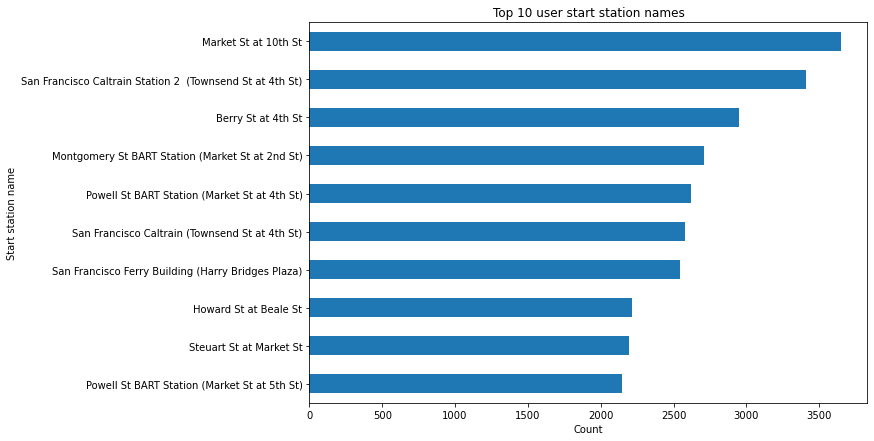

## The trips duration minutes

The average of the trip duration is 11.73 minutes

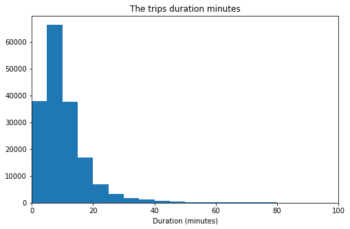

## Relationship between start day and gender

The most common day which bike users are Thursday from Males.

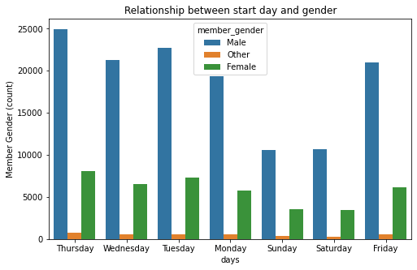

## Trip Duration by day and User Type

Depend on three factors (day, duration & user type), we notice that averagely customers spend time twice as much subscribers on daily basis; however, they tend to spend more time on weekends (Saturday & Sunday).

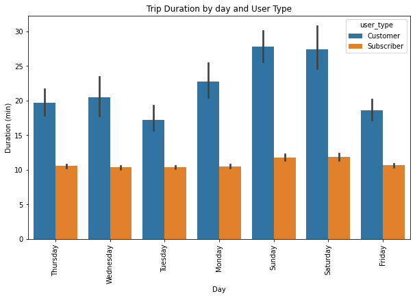

## Trip Duration by User Type and Gender

Depend on three factors (user type, duration & user gender), we notice that Customers rides much longer durations than subscribers no matter what the gender they are.

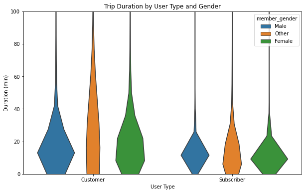